# Geography 176A

#Question3

```r
library(readr)
county_centroids <- read_csv("../data/county-centroids.csv")
head(county_centroids)
```

```
## # A tibble: 6 x 6
##      X1 fips  name       state_name     LON   LAT
##   <dbl> <chr> <chr>      <chr>        <dbl> <dbl>
## 1     1 39131 Pike       Ohio         -83.1  39.1
## 2     2 46003 Aurora     South Dakota -98.6  43.7
## 3     3 55035 Eau Claire Wisconsin    -91.3  44.7
## 4     4 72145 Vega Baja  Puerto Rico  -66.4  18.4
## 5     5 48259 Kendall    Texas        -98.7  29.9
## 6     6 40015 Caddo      Oklahoma     -98.4  35.2
```

```r
library(tidyverse)
library(ggplot2)
library(ggthemes)
county2 = county_centroids %>%
  select(county = name, LON, LAT, fips)
covid_xy = inner_join(covid, county2, by = c("county", "fips"))
xy1 <- covid_xy %>%
  mutate(xcoord = cases * LON, ycoord = cases * LAT) %>%
  group_by(date) %>%
  summarize(cases = sum(cases), xcoord = sum(xcoord), ycoord = sum(ycoord)) %>%
  mutate(longitude = xcoord / cases, latitude = ycoord / cases) %>%
  mutate(month = format(date, "%m"))
xy2 <- xy1 %>%
  group_by(month) %>%
  summarise(mocases = sum(cases))
xy3 <- inner_join(xy1, xy2, by = "month") %>%
  select(date, longitude, latitude)
knitr::kable(xy3, caption = "COVID-19 Weighted Mean", col.names = c("Date","Longitude","Latitude"))
```

COVID-19 Weighted Mean

| Date | Longitude | Latitude |
| --- | --- | --- |
| 2020-01-21 | -121.71707 | 48.04616 |
| 2020-01-22 | -121.71707 | 48.04616 |
| 2020-01-23 | -121.71707 | 48.04616 |
| 2020-01-24 | -104.76683 | 44.94380 |
| 2020-01-25 | -109.09942 | 41.19636 |
| 2020-01-26 | -111.60366 | 38.24914 |
| 2020-01-27 | -111.60366 | 38.24914 |
| 2020-01-28 | -111.60366 | 38.24914 |
| 2020-01-29 | -111.60366 | 38.24914 |
| 2020-01-30 | -107.63915 | 38.84786 |
| 2020-01-31 | -109.64744 | 38.61689 |
| 2020-02-01 | -104.82632 | 39.08077 |
| 2020-02-02 | -109.56226 | 38.67105 |
| 2020-02-03 | -109.56226 | 38.67105 |
| 2020-02-04 | -109.56226 | 38.67105 |
| 2020-02-05 | -107.88345 | 39.03726 |
| 2020-02-06 | -107.88345 | 39.03726 |
| 2020-02-07 | -107.88345 | 39.03726 |
| 2020-02-08 | -107.88345 | 39.03726 |
| 2020-02-09 | -107.88345 | 39.03726 |
| 2020-02-10 | -108.56428 | 38.57552 |
| 2020-02-11 | -108.56428 | 38.57552 |
| 2020-02-12 | -107.84690 | 37.92372 |
| 2020-02-13 | -107.22516 | 37.35883 |
| 2020-02-14 | -107.22516 | 37.35883 |
| 2020-02-15 | -107.22516 | 37.35883 |
| 2020-02-16 | -107.22516 | 37.35883 |
| 2020-02-17 | -102.79544 | 38.93337 |
| 2020-02-18 | -102.79544 | 38.93337 |
| 2020-02-19 | -102.79544 | 38.93337 |

[output cut: 206 more lines]

```r
xy4 <- xy2 %>%
  select(month, mocases)
knitr::kable(xy4, caption = "Monthly New Cases", col.names = c("Month","New Cases"))
```

[output not shown]

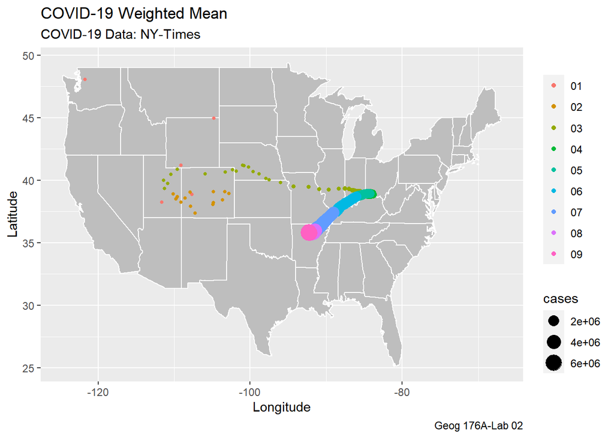

```r
ggplot(data = xy1, aes(x = longitude, y = latitude)) +
  borders("state", fill = "gray", colour = "white") +
  geom_point(aes(color = month, size = cases)) +
  labs(title = "COVID-19 Weighted Mean",
       x = "Longitude",
       y = "Latitude",
       caption = "Geog 176A-Lab 02",
       subtitle = "COVID-19 Data: NY-Times",
       color = "")
```

**Weight is a relative concept. The weight of the weighted average reflects the relative importance in the overall evaluation. The weight indicates that in the evaluation process, it is the quantitative allocation of the importance degree of different aspects of the evaluated object, and the role of each evaluation factor in the overall evaluation is treated differently. In fact, an evaluation without a focus is not an objective evaluation. Weight indicates how important certain data is in a set of data, so the weighted average effect must be studied in combination with specific examples. The size of the weighted average is not only related to each data in a set but is also affected by the weight of each data. The greater the weight.The greater the effect on the average size. The reverse is smaller.**